# Applied Data Analysis in Sport PG (10157), Semester 1 2022: Reproducible Data Analysis Project

Sreekar U3212459

[figure not shown]

## 1. Introduction

Every team owner wish to have top players only. But, its also a business and we need to “purchase!” only value for money players for maximum utilization of money. The report finds top 5 value for money players with the help of linear regression analysis performed with help of R packages(1).

The top 5 players are:

```
##   POSITION             PLAYER SALARYmillions
## 1       PG        Ben Simmons           6.43
## 2       SG       Devin Booker           3.31
## 3       SF     Brandon Ingram           5.75
## 4       PF      Julius Randle           8.64
## 5        C Karl-Anthony Towns           7.83
## 6                       TOTAL          31.96
```

### a) Description of scenario

Chicago Bulls is a Basketball team which participates in the NBA (National Basketball Association) seasons(2). General manager of Chicago Bulls has approached me, i.e. the author of this project; to find 5 best players for 5 positions, one player for each position for the next NBA season 2019-20.

### b) Background information

It is better to get some idea of the basketball game. Normally, a team has 5 players and these players are assigned to 5 positions. The basketball positions are assigned a number as under:

1. Point Guard [PG]

Main task of points guard is to score points. Besides that he should help in assists and limiting turnovers.

2. Shooting Guard [SG]

Main task of shooting guard is to score points. Besides that he should help in assists and limiting turnovers.

3. Small Forward [SF]

Main task of small forward is to score points. Besides that he should help in assists and limiting turnovers.

4. Power Forward [PF]

Main task of power forward is to score points. Besides that he should help in rebounds and limiting turnovers.

5. Center [C]

Rebounds, Blocking and limiting turnover are the key metrics for center.

### c) Aim of project

The aim of this project is to find out the 5 best players, one for each position for Chicago Bulls for the next session 2019-20. It may be noted that we are not going to just pick the top 5 players. We need to consider the budget and need to develop a model which identifies the undervalued players.

## 2. Reading and cleaning the raw data

### Date Description

The data set consists of 5 csv files. The data description is can be seen by clicking below link: https://github.com/Sreekardeshamoni/Assessment-4/blob/main/Data%20Description.pdf

### Loading tidyverse library and reading the data

The csv files are saved in data frames tibbles of readr package.

```r
library(tidyverse)
library(broom)
player_stat = read_csv("data/raw/2018-19_nba_player-statistics.csv")
player_salary = read_csv("data/raw/2018-19_nba_player-salaries.csv")
team_payroll = read_csv("data/raw/2019-20_nba_team-payroll.csv")
team_stat_1 = read_csv("data/raw/2018-19_nba_team-statistics_1.csv")
```

```
## * `` -> ...23
## * `` -> ...24
## * `` -> ...25
```

```r
team_stat_2 = read_csv("data/raw/2018-19_nba_team-statistics_2.csv")
```

Now, its time to have a look at data structure.

```r
str(player_stat)
```

```
## spec_tbl_df [708 × 29] (S3: spec_tbl_df/tbl_df/tbl/data.frame)
##  $ player_name: chr [1:708] "Alex Abrines" "Quincy Acy" "Jaylen Adams" "Steven Adams" ...
##  $ Pos        : chr [1:708] "SG" "PF" "PG" "C" ...
##  $ Age        : num [1:708] 25 28 22 25 21 21 25 33 21 23 ...
##  $ Tm         : chr [1:708] "OKC" "PHO" "ATL" "OKC" ...
##  $ G          : num [1:708] 31 10 34 80 82 19 7 81 10 38 ...
##  $ GS         : num [1:708] 2 0 1 80 28 3 0 81 1 2 ...
##  $ MP         : num [1:708] 588 123 428 2669 1913 ...
##  $ FG         : num [1:708] 56 4 38 481 280 11 3 684 13 67 ...
##  $ FGA        : num [1:708] 157 18 110 809 486 ...
##  $ FG%        : num [1:708] 0.357 0.222 0.345 0.595 0.576 0.306 0.3 0.519 0.333 0.376 ...
##  $ 3P         : num [1:708] 41 2 25 0 3 6 0 10 3 32 ...
##  $ 3PA        : num [1:708] 127 15 74 2 15 23 4 42 12 99 ...
##  $ 3P%        : num [1:708] 0.323 0.133 0.338 0 0.2 0.261 0 0.238 0.25 0.323 ...
##  $ 2P         : num [1:708] 15 2 13 481 277 5 3 674 10 35 ...
##  $ 2PA        : num [1:708] 30 3 36 807 471 ...
##  $ 2P%        : num [1:708] 0.5 0.667 0.361 0.596 0.588 0.385 0.5 0.528 0.37 0.443 ...
##  $ eFG%       : num [1:708] 0.487 0.278 0.459 0.595 0.579 0.389 0.3 0.522 0.372 0.466 ...
##  $ FT         : num [1:708] 12 7 7 146 166 4 1 349 8 45 ...
##  $ FTA        : num [1:708] 13 10 9 292 226 4 2 412 12 60 ...
##  $ FT%        : num [1:708] 0.923 0.7 0.778 0.5 0.735 1 0.5 0.847 0.667 0.75 ...
##  $ ORB        : num [1:708] 5 3 11 391 165 3 1 251 11 3 ...
##  $ DRB        : num [1:708] 43 22 49 369 432 16 3 493 15 20 ...
##  $ TRB        : num [1:708] 48 25 60 760 597 19 4 744 26 23 ...
##  $ AST        : num [1:708] 20 8 65 124 184 5 6 194 13 25 ...
##  $ STL        : num [1:708] 17 1 14 117 71 1 2 43 1 6 ...
##  $ BLK        : num [1:708] 6 4 5 76 65 4 0 107 0 6 ...
##  $ TOV        : num [1:708] 14 4 28 135 121 6 2 144 8 33 ...
##  $ PF         : num [1:708] 53 24 45 204 203 13 4 179 7 47 ...
##  $ PTS        : num [1:708] 165 17 108 1108 729 ...
##  - attr(*, "spec")=
##   .. cols(
##   ..   player_name = col_character(),
##   ..   Pos = col_character(),
##   ..   Age = col_double(),
##   ..   Tm = col_character(),
##   ..   G = col_double(),
##   ..   GS = col_double(),
##   ..   MP = col_double(),
##   ..   FG = col_double(),
```

[output cut: 8 more lines]

```
##   ..   `eFG%` = col_double(),
##   ..   FT = col_double(),
##   ..   FTA = col_double(),
##   ..   `FT%` = col_double(),
##   ..   ORB = col_double(),
##   ..   DRB = col_double(),
##   ..   TRB = col_double(),
##   ..   AST = col_double(),
##   ..   STL = col_double(),
##   ..   BLK = col_double(),
##   ..   TOV = col_double(),
##   ..   PF = col_double(),
##   ..   PTS = col_double()
##   .. )
##  - attr(*, "problems")=<externalptr>
```

```r
str(player_salary)
```

```
## spec_tbl_df [576 × 3] (S3: spec_tbl_df/tbl_df/tbl/data.frame)
##  $ player_id  : num [1:576] 1 2 3 4 5 6 7 8 9 10 ...
##  $ player_name: chr [1:576] "Alex Abrines" "Quincy Acy" "Steven Adams" "Jaylen Adams" ...
##  $ salary     : num [1:576] 3667645 213948 24157304 236854 2955840 ...
##  - attr(*, "spec")=
##   .. cols(
##   ..   player_id = col_double(),
##   ..   player_name = col_character(),
##   ..   salary = col_double()
##   .. )
##  - attr(*, "problems")=<externalptr>
```

```r
str(team_payroll)
```

```
## spec_tbl_df [30 × 3] (S3: spec_tbl_df/tbl_df/tbl/data.frame)
##  $ team_id: num [1:30] 1 2 3 4 5 6 7 8 9 10 ...
##  $ team   : chr [1:30] "Miami" "Golden State" "Oklahoma City" "Toronto" ...
##  $ salary : chr [1:30] "$153,171,497" "$146,291,276" "$144,916,427" "$137,793,831" ...
##  - attr(*, "spec")=
##   .. cols(
##   ..   team_id = col_double(),
##   ..   team = col_character(),
##   ..   salary = col_character()
##   .. )
##  - attr(*, "problems")=<externalptr>
```

```r
str(team_stat_1)
```

```
## spec_tbl_df [30 × 25] (S3: spec_tbl_df/tbl_df/tbl/data.frame)
##  $ Rk    : num [1:30] 1 2 3 4 5 6 7 8 9 10 ...
##  $ Team  : chr [1:30] "Milwaukee Bucks" "Golden State Warriors" "Toronto Raptors" "Utah Jazz" ...
##  $ Age   : num [1:30] 26.9 28.4 27.3 27.3 29.2 26.2 24.9 25.7 25.7 27 ...
##  $ W     : num [1:30] 60 57 58 50 53 53 54 49 49 48 ...
##  $ L     : num [1:30] 22 25 24 32 29 29 28 33 33 34 ...
##  $ PW    : num [1:30] 61 56 56 54 53 51 51 52 50 50 ...
##  $ PL    : num [1:30] 21 26 26 28 29 31 31 30 32 32 ...
##  $ MOV   : num [1:30] 8.87 6.46 6.09 5.26 4.77 4.2 3.95 4.44 3.4 3.33 ...
##  $ SOS   : num [1:30] -0.82 -0.04 -0.6 0.03 0.19 0.24 0.24 -0.54 0.15 -0.57 ...
##  $ SRS   : num [1:30] 8.04 6.42 5.49 5.28 4.96 4.43 4.19 3.9 3.56 2.76 ...
##  $ ORtg  : num [1:30] 114 116 113 111 116 ...
##  $ DRtg  : num [1:30] 105 110 107 106 111 ...
##  $ NRtg  : num [1:30] 8.6 6.4 6 5.2 4.8 4.2 4.1 4.4 3.3 3.4 ...
##  $ Pace  : num [1:30] 103.3 100.9 100.2 100.3 97.9 ...
##  $ FTr   : num [1:30] 0.255 0.227 0.247 0.295 0.279 0.258 0.232 0.215 0.266 0.242 ...
##  $ 3PAr  : num [1:30] 0.419 0.384 0.379 0.394 0.519 0.339 0.348 0.381 0.347 0.292 ...
##  $ TS%   : num [1:30] 0.583 0.596 0.579 0.572 0.581 0.568 0.558 0.567 0.545 0.561 ...
##  $ eFG%  : num [1:30] 0.55 0.565 0.543 0.538 0.542 0.528 0.527 0.534 0.514 0.53 ...
##  $ TOV%  : num [1:30] 12 12.6 12.4 13.4 12 12.1 11.9 11.5 11.7 12.4 ...
##  $ ORB%  : num [1:30] 20.8 22.5 21.9 22.9 22.8 26.6 26.6 21.6 26 21.9 ...
##  $ FT/FGA: num [1:30] 0.197 0.182 0.198 0.217 0.221 0.21 0.175 0.173 0.19 0.182 ...
##  $ DRB%  : num [1:30] 80.3 77.1 77.1 80.3 74.4 77.9 78 77 78.2 76.2 ...
##  $ ...23 : logi [1:30] NA NA NA NA NA NA ...
##  $ ...24 : logi [1:30] NA NA NA NA NA NA ...
##  $ ...25 : logi [1:30] NA NA NA NA NA NA ...
##  - attr(*, "spec")=
##   .. cols(
##   ..   Rk = col_double(),
##   ..   Team = col_character(),
##   ..   Age = col_double(),
##   ..   W = col_double(),
##   ..   L = col_double(),
##   ..   PW = col_double(),
##   ..   PL = col_double(),
##   ..   MOV = col_double(),
##   ..   SOS = col_double(),
##   ..   SRS = col_double(),
##   ..   ORtg = col_double(),
##   ..   DRtg = col_double(),
##   ..   NRtg = col_double(),
##   ..   Pace = col_double(),
##   ..   FTr = col_double(),
##   ..   `3PAr` = col_double(),
##   ..   `TS%` = col_double(),
##   ..   `eFG%` = col_double(),
##   ..   `TOV%` = col_double(),
##   ..   `ORB%` = col_double(),
##   ..   `FT/FGA` = col_double(),
##   ..   `DRB%` = col_double(),
##   ..   ...23 = col_logical(),
##   ..   ...24 = col_logical(),
##   ..   ...25 = col_logical()
##   .. )
##  - attr(*, "problems")=<externalptr>
```

```r
str(team_stat_2)
```

```
## spec_tbl_df [30 × 25] (S3: spec_tbl_df/tbl_df/tbl/data.frame)
##  $ Rk  : num [1:30] 1 2 3 4 5 6 7 8 9 10 ...
##  $ Team: chr [1:30] "Milwaukee Bucks" "Golden State Warriors" "New Orleans Pelicans" "Philadelphia 76ers" ...
##  $ G   : num [1:30] 82 82 82 82 82 82 82 82 82 82 ...
##  $ MP  : num [1:30] 19780 19805 19755 19805 19830 ...
##  $ FG  : num [1:30] 3555 3612 3581 3407 3384 ...
##  $ FGA : num [1:30] 7471 7361 7563 7233 7178 ...
##  $ FG% : num [1:30] 0.476 0.491 0.473 0.471 0.471 0.467 0.454 0.474 0.464 0.468 ...
##  $ 3P  : num [1:30] 1105 1087 842 889 821 ...
##  $ 3PA : num [1:30] 3134 2824 2449 2474 2118 ...
##  $ 3P% : num [1:30] 0.353 0.385 0.344 0.359 0.388 0.359 0.348 0.366 0.378 0.341 ...
##  $ 2P  : num [1:30] 2450 2525 2739 2518 2563 ...
##  $ 2PA : num [1:30] 4337 4537 5114 4759 5060 ...
##  $ 2P% : num [1:30] 0.565 0.557 0.536 0.529 0.507 0.523 0.51 0.539 0.504 0.543 ...
##  $ FT  : num [1:30] 1471 1339 1462 1742 1853 ...
##  $ FTA : num [1:30] 1904 1672 1921 2258 2340 ...
##  $ FT% : num [1:30] 0.773 0.801 0.761 0.771 0.792 0.814 0.713 0.804 0.726 0.768 ...
##  $ ORB : num [1:30] 762 797 909 892 796 ...
##  $ DRB : num [1:30] 3316 2990 2969 3025 2936 ...
##  $ TRB : num [1:30] 4078 3787 3878 3917 3732 ...
##  $ AST : num [1:30] 2136 2413 2216 2207 1970 ...
##  $ STL : num [1:30] 615 625 610 606 561 546 766 680 679 683 ...
##  $ BLK : num [1:30] 486 525 441 432 385 413 425 437 363 379 ...
##  $ TOV : num [1:30] 1137 1169 1215 1223 1193 ...
##  $ PF  : num [1:30] 1608 1757 1732 1745 1913 ...
##  $ PTS : num [1:30] 9686 9650 9466 9445 9442 ...
##  - attr(*, "spec")=
##   .. cols(
##   ..   Rk = col_double(),
##   ..   Team = col_character(),
##   ..   G = col_double(),
##   ..   MP = col_double(),
##   ..   FG = col_double(),
##   ..   FGA = col_double(),
##   ..   `FG%` = col_double(),
##   ..   `3P` = col_double(),
##   ..   `3PA` = col_double(),
##   ..   `3P%` = col_double(),
##   ..   `2P` = col_double(),
##   ..   `2PA` = col_double(),
##   ..   `2P%` = col_double(),
##   ..   FT = col_double(),
##   ..   FTA = col_double(),
##   ..   `FT%` = col_double(),
##   ..   ORB = col_double(),
##   ..   DRB = col_double(),
##   ..   TRB = col_double(),
##   ..   AST = col_double(),
##   ..   STL = col_double(),
##   ..   BLK = col_double(),
##   ..   TOV = col_double(),
##   ..   PF = col_double(),
##   ..   PTS = col_double()
##   .. )
##  - attr(*, "problems")=<externalptr>
```

R can manage the “illegal” variable names by surrounding the variable name by ``, however, as a best practice it makes sense to rename the variables.

```r
player_stat <-rename(player_stat,
                    FGp = `FG%`,
                    x3P = `3P`,
                    x3PA = `3PA`,
                    x3Pp = `3P%`,
                    x2P = `2P`,
                    x2PA = `2PA`,
                    x2Pp = `2P%`,
                    eFGp = `eFG%`,
                    FTp = `FT%`)

team_stat_1 <-rename(team_stat_1,
                           x3PAr = `3PAr`,
                           TSp = `TS%`,
                           eFGp = `eFG%`,
                           TOVp = `TOV%`,
                           ORBp = `ORB%`,
                           FTpFGA = `FT/FGA`,
                           DRBp = `DRB%`)

team_stat_2 <-rename(team_stat_2,
                           FGp = `FG%`,
                           x3P = `3P`,
                           x3PA = `3PA`,
                           x3Pp = `3P%`,
                           x2P = `2P`,
                           x2PA = `2PA`,
                           x2Pp = `2P%`,
                           FTp = `FT%`)
```

## 3. Exploratory analysis

### Checking missing values player_stat

At first need to check the missing values.

```r
sum(is.na(player_stat))
```

```
## [1] 117
```

```r
which(is.na(player_stat), arr.ind = TRUE)
```

```
##        row col
##   [1,] 303  10
##   [2,] 371  10
##   [3,] 478  10
##   [4,] 600  10
##   [5,] 614  10
##   [6,] 652  10
##   [7,]  19  13
##   [8,]  21  13
##   [9,]  59  13
##  [10,]  66  13
##  [11,]  74  13
##  [12,] 113  13
##  [13,] 126  13
##  [14,] 132  13
```

[output cut: 103 more lines]

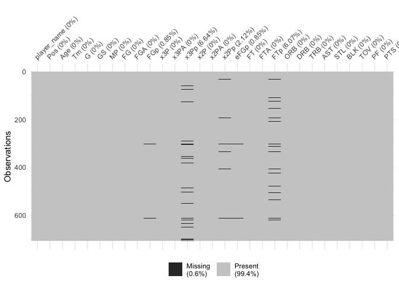

```r
naniar::vis_miss(player_stat)
```

There are missing values for FGp, x3Pp, x2Pp, eFGp, and FTp. These are calculated field in the raw data itself, and where the denominator and/or numerator is zero, these fields becomes NA. However, it is understood that these are values where field goal, 2 Pointer and 3 Pointer was not done by the player. Hence, it is a good idea to replace these values by 0%.

```r
player_stat <- replace_na(player_stat, list(FGp = 0,x3Pp = 0,x2Pp = 0, eFGp = 0, FTp = 0))
sum(is.na(player_stat))
```

```
## [1] 0
```

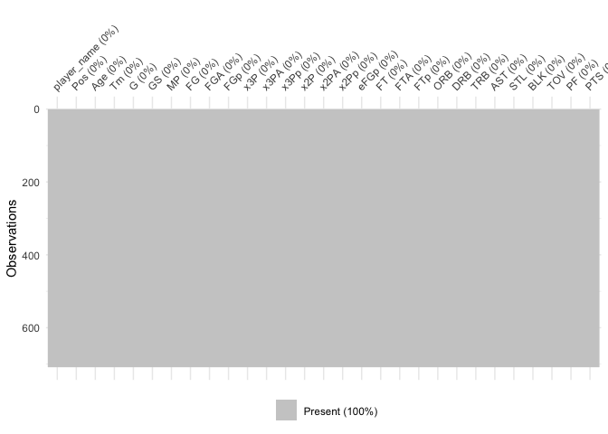

```r
naniar::vis_miss(player_stat)
```

If we check the player_name variable, we find that a total of 86 players have played for more than 1 team in the season. mydf1 = df1 %>% group_by(player_name) %>% summarise(num_of_teams =n()) %>% filter(num_of_teams>1)

### Checking missing values player_salary

```r
sum(is.na(player_salary))
```

```
## [1] 0
```

```r
which(is.na(player_salary), arr.ind = TRUE)
```

```
##      row col
```

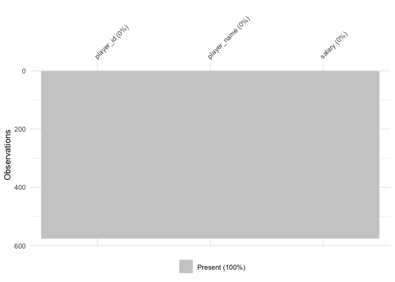

```r
naniar::vis_miss(player_salary)
```

### Checking missing values team_payroll

```r
sum(is.na(team_payroll))
```

```
## [1] 0
```

```r
which(is.na(team_payroll), arr.ind = TRUE)
```

```
##      row col
```

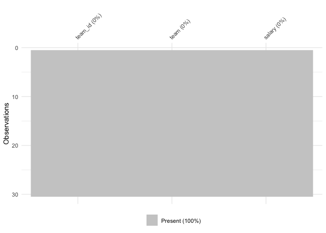

```r
naniar::vis_miss(team_payroll)
```

### Checking missing values team_stat_1

```r
sum(is.na(team_stat_1))
```

```
## [1] 90
```

```r
which(is.na(team_stat_1), arr.ind = TRUE)
```

```
##       row col
##  [1,]   1  23
##  [2,]   2  23
##  [3,]   3  23
##  [4,]   4  23
##  [5,]   5  23
##  [6,]   6  23
##  [7,]   7  23
##  [8,]   8  23
##  [9,]   9  23
## [10,]  10  23
## [11,]  11  23
## [12,]  12  23
## [13,]  13  23
## [14,]  14  23
```

[output cut: 76 more lines]

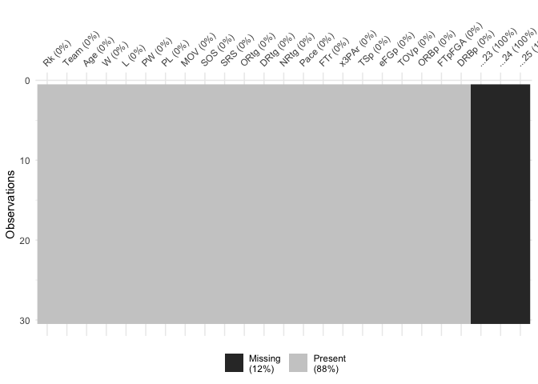

```r
naniar::vis_miss(team_stat_1)
```

team_stat_1 has last 3 columns …23, …24, …25 and these appears to be bogus columns and there is need to deleted these columns. The tidy team_stat_1 shall be as under:

```r
team_stat_1 = select(team_stat_1,-c(...23:...25))
team_stat_1
```

```
## # A tibble: 30 x 22
##       Rk Team    Age     W     L    PW    PL   MOV   SOS   SRS  ORtg  DRtg  NRtg
##    <dbl> <chr> <dbl> <dbl> <dbl> <dbl> <dbl> <dbl> <dbl> <dbl> <dbl> <dbl> <dbl>
##  1     1 Milw…  26.9    60    22    61    21  8.87 -0.82  8.04  114.  105.   8.6
##  2     2 Gold…  28.4    57    25    56    26  6.46 -0.04  6.42  116.  110.   6.4
##  3     3 Toro…  27.3    58    24    56    26  6.09 -0.6   5.49  113.  107.   6
##  4     4 Utah…  27.3    50    32    54    28  5.26  0.03  5.28  111.  106.   5.2
##  5     5 Hous…  29.2    53    29    53    29  4.77  0.19  4.96  116.  111.   4.8
##  6     6 Port…  26.2    53    29    51    31  4.2   0.24  4.43  115.  110.   4.2
##  7     7 Denv…  24.9    54    28    51    31  3.95  0.24  4.19  113   109.   4.1
##  8     8 Bost…  25.7    49    33    52    30  4.44 -0.54  3.9   112.  108.   4.4
##  9     9 Okla…  25.7    49    33    50    32  3.4   0.15  3.56  110.  107    3.3
## 10    10 Indi…  27      48    34    50    32  3.33 -0.57  2.76  110.  106.   3.4
## # … with 20 more rows, and 9 more variables: Pace <dbl>, FTr <dbl>,
## #   x3PAr <dbl>, TSp <dbl>, eFGp <dbl>, TOVp <dbl>, ORBp <dbl>, FTpFGA <dbl>,
## #   DRBp <dbl>
```

Now, the bogus columns are gone. This can be crossed checked:

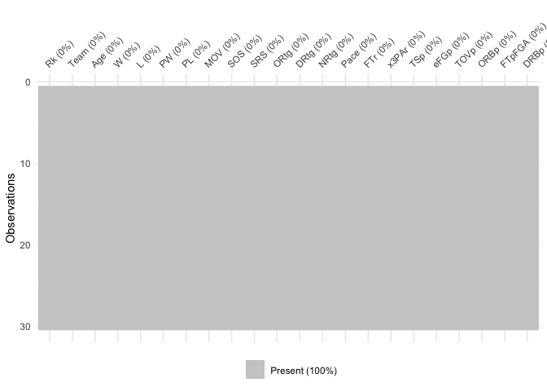

```r
naniar::vis_miss(team_stat_1)
```

### Checking missing values team_stat_2

```r
sum(is.na(team_stat_2))
```

```
## [1] 0
```

```r
which(is.na(team_stat_2), arr.ind = TRUE)
```

```
##      row col
```

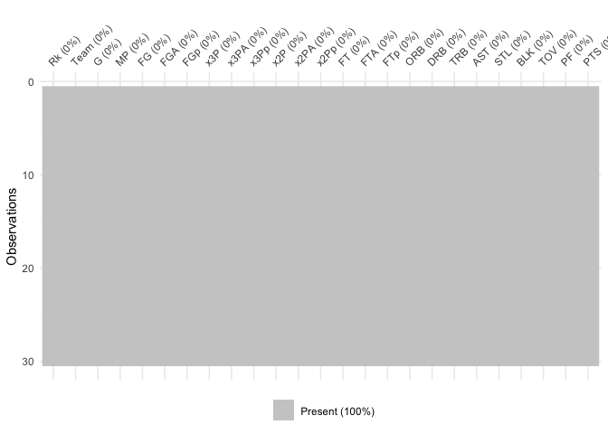

```r
naniar::vis_miss(team_stat_2)
```

We can combine team_stat_1 and team_stat_2.

```r
team_stat <- left_join(x = team_stat_1[-1], y = team_stat_2[-1], by = "Team") #don't need cols 1 of Ranks
```

### Other aspects

Interesting fact is that there are 30 teams, but in the player statistics table, there are 31 teams.We find that extra team is TOT which represents the total of all the instances matrices,where a player played from 2 or more teams in the season. We need the total of performance done by such players for the teams they were playing. This can be get with row where team name is “TOT”. Thus, fur such players,we can keep only the row having “TOT” as team.

```r
player_stat <- player_stat %>% group_by(player_name) %>% add_tally() %>% filter(n==1 | n>1 & Tm == "TOT")
```

```r
player_stat <- player_stat %>% separate(col = Pos, into = "Pos")
```

Also, some of the players have played a lower number of games. In fact, there are 20 players who have played only 1 game. We need to create a sort of cutoff and minimum 10 games cutoff is a reasonable cut off.

```r
player_stat <- player_stat %>% filter(G>=10)
```

There are 576 players in players salary table, however, there are only 530 unique players in the player statistics table. It means that some of the players did not played in NBA or the data for them is not available in player statistics. However, this fact is considered unimportant for the given project analysis. We can combine player_salary and player_stat

```r
player_stat <- inner_join(x = player_stat, y = player_salary, by = "player_name")
```

## 4. Data modelling and results

### Valuing Players

The main purpose of any basketball game is that the team wins that game. However, wining of games cannot alone a factor to select the players. In fact only team wins the matches and a player alone cannot have a credit to win the game and basket ball is a team game. Thus, we need find some metrics which includes several indirect measures to rate the players. A player alone may not win the game but it can score points. Points win the games and and after all players are recruited to score points. Now, we will create a metric to value the players based upon certain factors/variables. This metric can be called exp_PTS_per_game. We shall then identify the undervalue players with the help of this metric(3).

In order to predict the exp_PTS_per_game, we need to find some key variables for our analysis(4). There after we will perform a multiple linear regression model.

Some of the metrics to be used are below:

TRB Total Rebounds

AST Assists

STL Steals

BLK Blocks

TOV Turnovers

However, as number of games played by players are different, it makes sense to normalize these metrics per game.

```r
normalised_team_stat <- team_stat %>% mutate(
  PTS_per_game = PTS / G,
  TRB_per_game = TRB / G,
  AST_per_game = AST / G,
  STL_per_game = STL / G,
  BLK_per_game = BLK / G,
  TOV_per_game = TOV / G)
```

Checking that PTS_per_game is correlated with Wins or not…

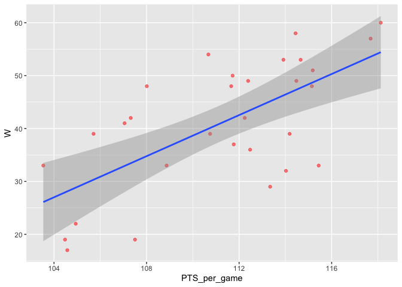

```r
ggplot(normalised_team_stat, aes(x = PTS_per_game, y = W))+
geom_point(alpha = 0.5, colour = "red")+
geom_smooth(method = "lm")
```

```r
#checking correlation between Win and Points_per_game
cor(x = normalised_team_stat$PTS_per_game, y = normalised_team_stat$W, method = "pearson")
```

```
## [1] 0.6606001
```

Thus, we can see that Points_per_game has a positive correlation with Win.

Before developing a multiple regression model for PTS_per_game we should see confirm that dependent variable PTS_per_game and independent variables are related.

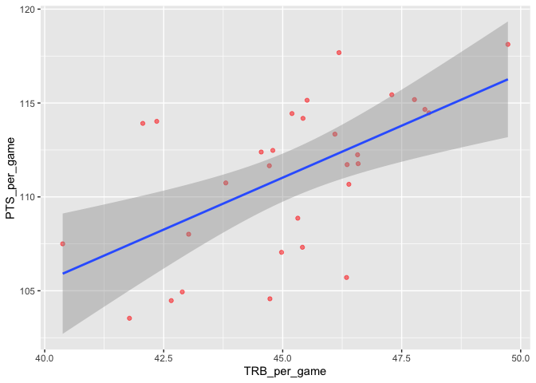

```r
ggplot(normalised_team_stat, aes(x = TRB_per_game, y = PTS_per_game))+
geom_point(alpha = 0.5, colour = "red") +
geom_smooth(method = "lm")
```

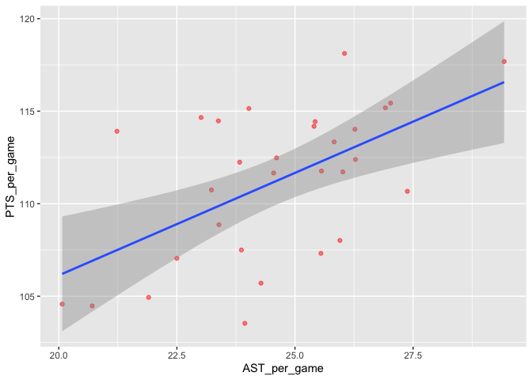

```r
ggplot(normalised_team_stat, aes(x = AST_per_game, y = PTS_per_game))+
geom_point(alpha = 0.5, colour = "red") +
geom_smooth(method = "lm")
```

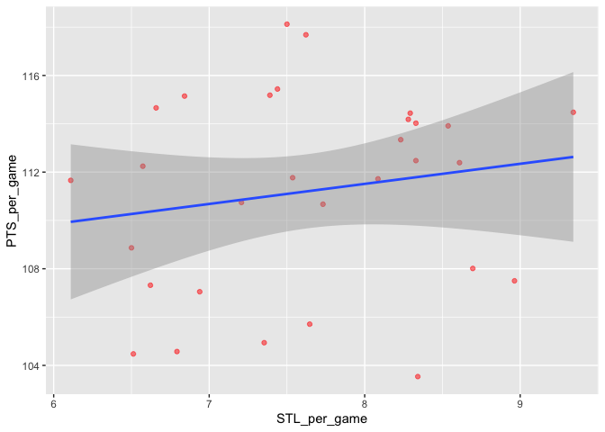

```r
ggplot(normalised_team_stat, aes(x = STL_per_game, y = PTS_per_game))+
geom_point(alpha = 0.5, colour = "red") +
geom_smooth(method = "lm")
```

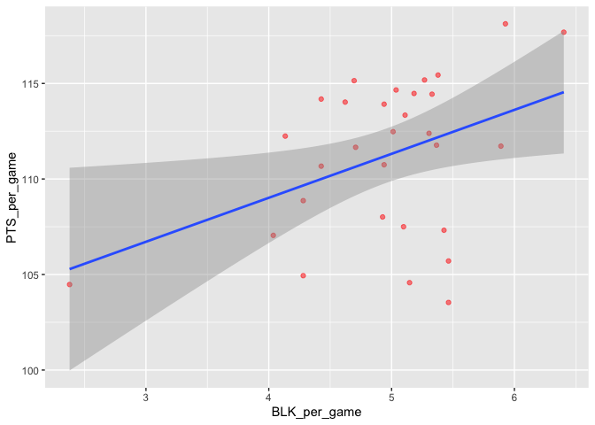

```r
ggplot(normalised_team_stat, aes(x = BLK_per_game, y = PTS_per_game))+
geom_point(alpha = 0.5, colour = "red") +
geom_smooth(method = "lm")
```

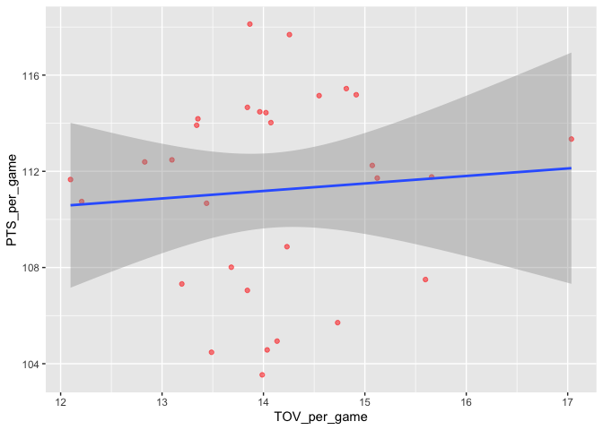

```r
ggplot(normalised_team_stat, aes(x = TOV_per_game, y = PTS_per_game))+
geom_point(alpha = 0.5, colour = "red") +
geom_smooth(method = "lm")
```

We can see that variables has a linear relations. Now, we create a multiple regression model for exp_PTS_per_game.

```r
fit <- lm(PTS_per_game ~
  TRB_per_game  + AST_per_game  + STL_per_game  + BLK_per_game  + TOV_per_game, data = normalised_team_stat)
tidy(fit, conf.int = TRUE)
```

```
## # A tibble: 6 x 7
##   term         estimate std.error statistic p.value conf.low conf.high
##   <chr>           <dbl>     <dbl>     <dbl>   <dbl>    <dbl>     <dbl>
## 1 (Intercept)    47.5      16.4       2.90  0.00785  13.7       81.4
## 2 TRB_per_game    1.01      0.341     2.97  0.00666   0.309      1.72
## 3 AST_per_game    0.663     0.353     1.88  0.0724   -0.0651     1.39
## 4 STL_per_game    1.11      0.834     1.33  0.196    -0.612      2.83
## 5 BLK_per_game   -0.116     1.05     -0.111 0.913    -2.28       2.05
## 6 TOV_per_game   -0.447     0.593    -0.753 0.459    -1.67       0.778
```

**Our Model says:**

**$expPTSpergame = RBpergame + ASTpergame + STLpergame + BLKpergame + TOVpergame$**

### Checking Multiple Linear Regression Assumptions

**1. The dependent variable should be continuous.**

Yes, The Points_per_game is a continuous variable.

**2. The independent variables should be continuous**

Yes, Each of the independent variables is continuous.

**3. Independence of observations**

```r
car::durbinWatsonTest(fit)
```

```
##  lag Autocorrelation D-W Statistic p-value
##    1     -0.09644946      2.179861   0.688
##  Alternative hypothesis: rho != 0
```

The DW statistics value of 2 indicates that there is no correlation at all. We can see that in our model the value is almost 2. This indicates there is almost no correlation at all among the residuals and that we have independence of observations.

**4. Linearity**

The dependent variable should have a linear relationship with each independent variable.

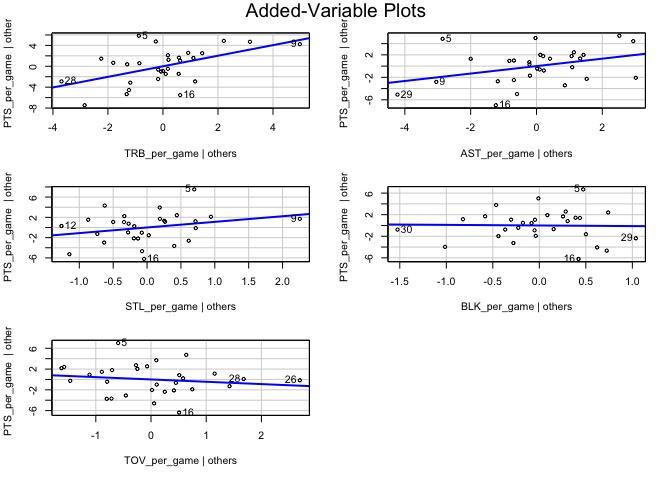

```r
car::avPlots(fit)
```

We can see a linear relationship, Though it is weak in case of BLK-per_game.

**5. Outliers**

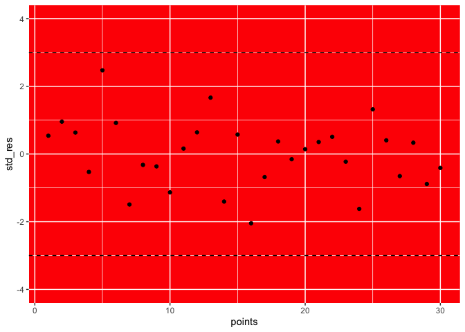

```r
#Check the data for outliers.
std_res <- rstandard(fit)
points <- 1:length(std_res)
ggplot(data = NULL, aes(x = points, y = std_res)) +
geom_point(colour = "black") +
ylim(c(-4, 4)) +
geom_hline(yintercept = c(-3, 3), colour = "black", linetype = "dashed")+
theme(panel.background = element_rect(fill = 'red'))
```

**6. Homoscedasticity**

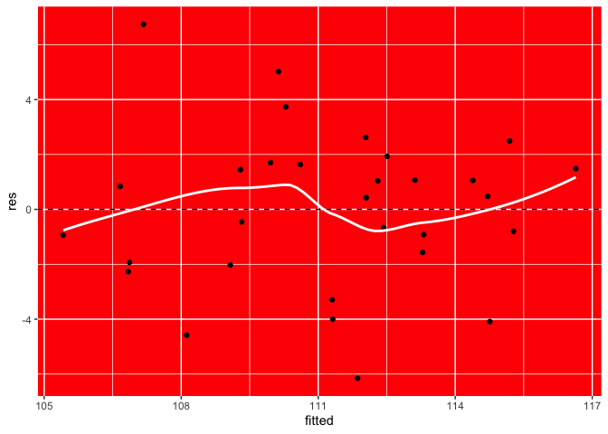

```r
res<- residuals(fit)
fitted <- fit %>%  predict()
ggplot(normalised_team_stat, aes(x = fitted, y = res))+
geom_point(colour = "black")+
geom_hline(yintercept = 0, colour = "black", linetype = "dashed")+
theme(panel.background = element_rect(fill = 'red'))+
geom_smooth(se = FALSE, colour = "white")
```

Yes, the data shows homoscedasticity evident from randomisation visible.

**7. Normality**

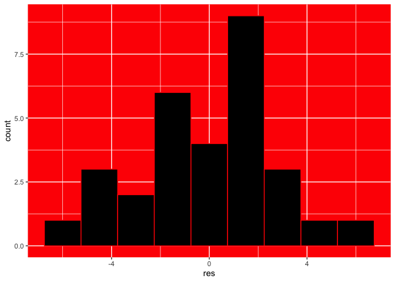

```r
ggplot(data =NULL, aes(x= res))+
geom_histogram( colour = "red", fill = "black", binwidth = 1.5)+
theme(panel.background = element_rect(fill = 'red'))
```

Yes, the data points appear normally distributed.

**8. Multicollinearity**

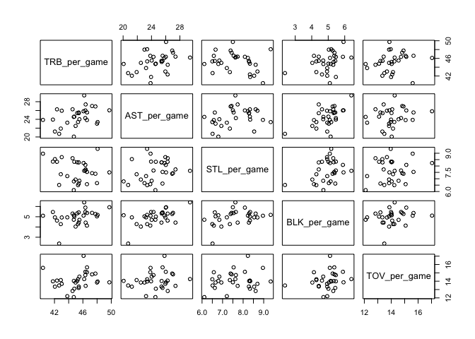

```r
pairs(formula = ~ TRB_per_game  + AST_per_game  + STL_per_game  + BLK_per_game  + TOV_per_game, data = normalised_team_stat)
```

```r
car::vif(fit)
```

```
## TRB_per_game AST_per_game STL_per_game BLK_per_game TOV_per_game
##     1.532366     1.598148     1.457992     1.713277     1.088499
```

```r
sqrt(car::vif(fit))
```

```
## TRB_per_game AST_per_game STL_per_game BLK_per_game TOV_per_game
##     1.237888     1.264179     1.207474     1.308922     1.043311
```

The model does not show any multicollinearity and this is the required aspect.

### Model Testing & Player Metric

**Applying the model**

```r
normalised_team_stat <- mutate(normalised_team_stat,exp_PTS_per_game=predict(fit,newdata=normalised_team_stat))
```

graph

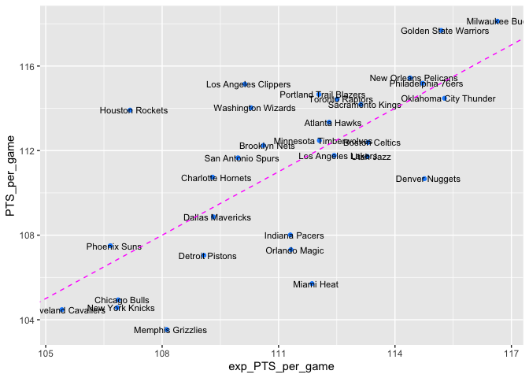

```r
ggplot(normalised_team_stat, aes(exp_PTS_per_game, PTS_per_game, label = Team)) +
geom_point(colour = "dodgerblue") +
geom_text(nudge_x = 0.1, cex = 3) +
geom_abline(linetype = "dashed", colour = "magenta")
```

graph

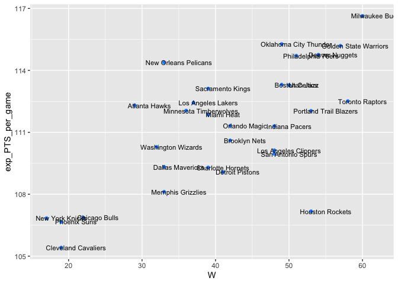

```r
ggplot(normalised_team_stat, aes(x = W, y = exp_PTS_per_game, label = Team)) +
geom_point(colour = "dodgerblue") +
geom_text(nudge_x = 2, cex = 3)
```

**Player Metric**

At first we normalize the player_stat

```r
normalised_player_stat <- player_stat %>% mutate(
  PTS_per_game = PTS / G,
  TRB_per_game = TRB / G,
  AST_per_game = AST / G,
  STL_per_game = STL / G,
  BLK_per_game = BLK / G,
  TOV_per_game = TOV / G)
str(normalised_player_stat)
```

```
## grouped_df [454 × 38] (S3: grouped_df/tbl_df/tbl/data.frame)
##  $ player_name : chr [1:454] "Alex Abrines" "Quincy Acy" "Jaylen Adams" "Steven Adams" ...
##  $ Pos         : chr [1:454] "SG" "PF" "PG" "C" ...
##  $ Age         : num [1:454] 25 28 22 25 21 21 33 21 23 20 ...
##  $ Tm          : chr [1:454] "OKC" "PHO" "ATL" "OKC" ...
##  $ G           : num [1:454] 31 10 34 80 82 19 81 10 38 80 ...
##  $ GS          : num [1:454] 2 0 1 80 28 3 81 1 2 80 ...
##  $ MP          : num [1:454] 588 123 428 2669 1913 ...
##  $ FG          : num [1:454] 56 4 38 481 280 11 684 13 67 335 ...
##  $ FGA         : num [1:454] 157 18 110 809 486 ...
##  $ FGp         : num [1:454] 0.357 0.222 0.345 0.595 0.576 0.306 0.519 0.333 0.376 0.59 ...
##  $ x3P         : num [1:454] 41 2 25 0 3 6 10 3 32 6 ...
##  $ x3PA        : num [1:454] 127 15 74 2 15 23 42 12 99 45 ...
##  $ x3Pp        : num [1:454] 0.323 0.133 0.338 0 0.2 0.261 0.238 0.25 0.323 0.133 ...
##  $ x2P         : num [1:454] 15 2 13 481 277 5 674 10 35 329 ...
##  $ x2PA        : num [1:454] 30 3 36 807 471 ...
##  $ x2Pp        : num [1:454] 0.5 0.667 0.361 0.596 0.588 0.385 0.528 0.37 0.443 0.629 ...
##  $ eFGp        : num [1:454] 0.487 0.278 0.459 0.595 0.579 0.389 0.522 0.372 0.466 0.595 ...
##  $ FT          : num [1:454] 12 7 7 146 166 4 349 8 45 197 ...
##  $ FTA         : num [1:454] 13 10 9 292 226 4 412 12 60 278 ...
##  $ FTp         : num [1:454] 0.923 0.7 0.778 0.5 0.735 1 0.847 0.667 0.75 0.709 ...
##  $ ORB         : num [1:454] 5 3 11 391 165 3 251 11 3 191 ...
##  $ DRB         : num [1:454] 43 22 49 369 432 16 493 15 20 481 ...
##  $ TRB         : num [1:454] 48 25 60 760 597 19 744 26 23 672 ...
##  $ AST         : num [1:454] 20 8 65 124 184 5 194 13 25 110 ...
##  $ STL         : num [1:454] 17 1 14 117 71 1 43 1 6 43 ...
##  $ BLK         : num [1:454] 6 4 5 76 65 4 107 0 6 120 ...
##  $ TOV         : num [1:454] 14 4 28 135 121 6 144 8 33 103 ...
##  $ PF          : num [1:454] 53 24 45 204 203 13 179 7 47 184 ...
##  $ PTS         : num [1:454] 165 17 108 1108 729 ...
##  $ n           : int [1:454] 1 1 1 1 1 1 1 1 1 1 ...
##  $ player_id   : num [1:454] 1 2 4 3 5 6 10 11 12 13 ...
##  $ salary      : num [1:454] 3667645 213948 236854 24157304 2955840 ...
##  $ PTS_per_game: num [1:454] 5.32 1.7 3.18 13.85 8.89 ...
##  $ TRB_per_game: num [1:454] 1.55 2.5 1.76 9.5 7.28 ...
##  $ AST_per_game: num [1:454] 0.645 0.8 1.912 1.55 2.244 ...
##  $ STL_per_game: num [1:454] 0.548 0.1 0.412 1.462 0.866 ...
##  $ BLK_per_game: num [1:454] 0.194 0.4 0.147 0.95 0.793 ...
##  $ TOV_per_game: num [1:454] 0.452 0.4 0.824 1.688 1.476 ...
##  - attr(*, "groups")= tibble [454 × 2] (S3: tbl_df/tbl/data.frame)
```

[output cut: 89 more lines]

[output not shown]

Next, step is to calculate player specific expected points.

```r
fit <- lm(PTS_per_game ~
  TRB_per_game  + AST_per_game  + STL_per_game  + BLK_per_game  + TOV_per_game, data = normalised_player_stat)
tidy(fit, conf.int = TRUE)
```

```
## # A tibble: 6 x 7
##   term         estimate std.error statistic  p.value conf.low conf.high
##   <chr>           <dbl>     <dbl>     <dbl>    <dbl>    <dbl>     <dbl>
## 1 (Intercept)    0.357     0.287      1.24  2.14e- 1   -0.207     0.920
## 2 TRB_per_game   0.368     0.0929     3.96  8.59e- 5    0.186     0.551
## 3 AST_per_game  -0.587     0.173     -3.39  7.48e- 4   -0.927    -0.247
## 4 STL_per_game   2.58      0.497      5.19  3.14e- 7    1.60      3.56
## 5 BLK_per_game  -0.0830    0.473     -0.175 8.61e- 1   -1.01      0.847
## 6 TOV_per_game   6.15      0.418     14.7   3.19e-40    5.33      6.97
```

```r
normalised_player_stat <- normalised_player_stat%>% ungroup() %>% mutate(exp_PTS = predict(fit,newdata = normalised_player_stat))
```

histogram

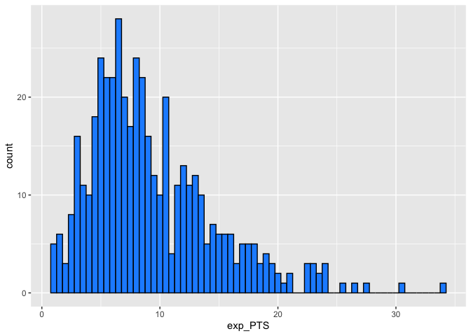

```r
normalised_player_stat %>%
ggplot(aes(x = exp_PTS)) +
geom_histogram(binwidth = 0.5, colour = "black", fill = "dodgerblue")
```

## 5. Player recommendations

### Value for money player for Point Guard Position

```
## # A tibble: 10 x 4
##    player_name       Pos     salary exp_PTS
##    <chr>             <chr>    <dbl>   <dbl>
##  1 James Harden      PG    30570000    34.1
##  2 Russell Westbrook PG    35665000    30.5
##  3 Ben Simmons       PG     6434520    24.0
##  4 John Wall         PG    19169800    23.7
##  5 Trae Young        PG     5363280    22.7
##  6 D'Angelo Russell  PG     7019698    20.1
##  7 Stephen Curry     PG    37457154    19.8
##  8 Dennis Smith      PG     3819960    19.7
##  9 De'Aaron Fox      PG     5470920    18.9
## 10 Chris Paul        PG    35654150    18.4
```

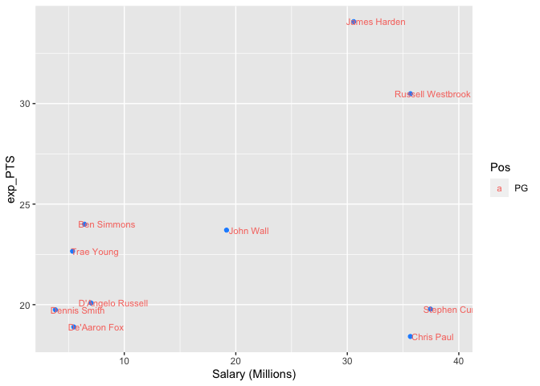

[figure not shown]

Ben Simmons & Trae Young are two players best suited for point guard position. We can see that Ben Simmons has exp_PTS of 24.0 at just 6.43 millions. So, he is our player for point guard position. More detail of players can be see at NBA website(5). We can consider Trae Young for bench strength.

### Value for money player for Shooting Guard Position

```
## # A tibble: 10 x 4
##    player_name      Pos     salary exp_PTS
##    <chr>            <chr>    <dbl>   <dbl>
##  1 Devin Booker     SG     3314365    25.5
##  2 Luka Doncic      SG     6569040    23.6
##  3 Zach LaVine      SG    19500000    22.9
##  4 Jrue Holiday     SG    26641111    21.1
##  5 Donovan Mitchell SG     3111480    20.3
##  6 Bradley Beal     SG    25434262    19.5
##  7 DeMar DeRozan    SG    27739975    17.7
##  8 Victor Oladipo   SG    21000000    17.7
##  9 Josh Jackson     SG     6041520    16.4
## 10 Dwyane Wade      SG     2393887    15.6
```

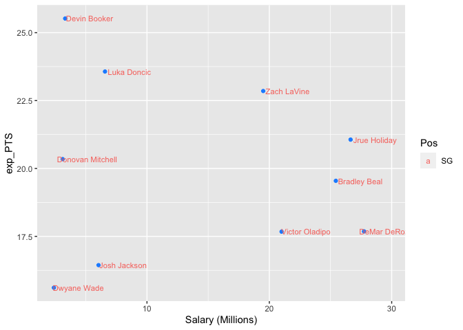

[figure not shown]

Devin Booker & Luka Doncic are two players best suited for shooting guard position. We can see that Devin Booker has exp_PTS of 25.5 just at 3.31 millions. So, he is our player for shooting guard position. We can put Luka Doncic for bench strength.

### Value for money player for Small Forward Position

```
## # A tibble: 10 x 4
##    player_name      Pos     salary exp_PTS
##    <chr>            <chr>    <dbl>   <dbl>
##  1 LeBron James     SF    35654150    24.0
##  2 Paul George      SF    30560700    23.0
##  3 Kevin Durant     SF    30000000    18.8
##  4 Kawhi Leonard    SF    23114066    18.0
##  5 Brandon Ingram   SF     5757120    17.1
##  6 Khris Middleton  SF    13000000    16.6
##  7 Justise Winslow  SF     3448926    15.9
##  8 Robert Covington SF    10464092    15.2
##  9 Andrew Wiggins   SF    25467250    14.7
## 10 Jimmy Butler     SF    19841627    13.7
```

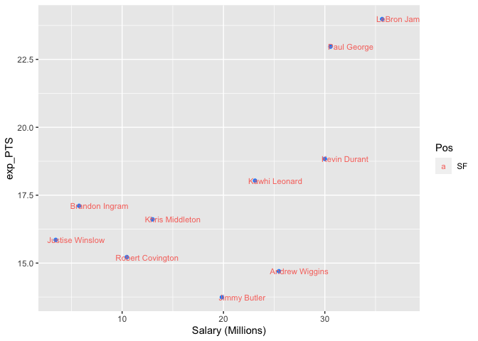

[figure not shown]

Brandon Ingram & Justise Winslow are two players for small forward position. We can see that Brandon Ingram has exp_PTS of 17.1 just at 5.75 millions. So, he is our player for small forward position. We can put Justise Winslow for bench strength.

### Value for money player for Power Forward Position

```
## # A tibble: 10 x 4
##    player_name           Pos     salary exp_PTS
##    <chr>                 <chr>    <dbl>   <dbl>
##  1 Giannis Antetokounmpo PF    24157304    27.6
##  2 Blake Griffin         PF    31873932    22.5
##  3 Julius Randle         PF     8641000    21.0
##  4 Draymond Green        PF    17469565    18.4
##  5 Jabari Parker         PF    20000000    17.7
##  6 Joe Ingles            PF    12545455    16.0
##  7 John Collins          PF     2299080    15.8
##  8 Kevin Love            PF    24119025    15.5
##  9 Aaron Gordon          PF    21590909    15.5
## 10 Pascal Siakam         PF     1544951    15.2
```

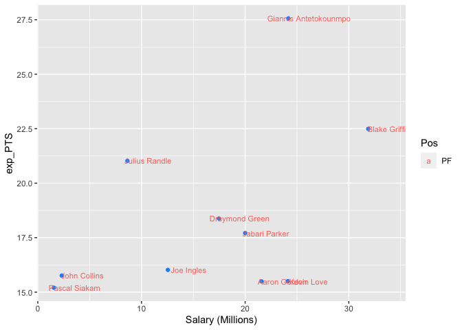

[figure not shown]

Julius Randle & John Collins are two best players for power forward position. We can see that Julius Randle has exp_PTS of 21 at just 8.64 millions. So, he is our player for power forward position. We can put John Collins for bench strenght.

### Value for money player for Center Position

```
## # A tibble: 10 x 4
##    player_name        Pos     salary exp_PTS
##    <chr>              <chr>    <dbl>   <dbl>
##  1 Joel Embiid        C     25467250    26.6
##  2 Karl-Anthony Towns C      7839435    24.2
##  3 Andre Drummond     C     25434262    23.2
##  4 Nikola Jokic       C     25467250    22.6
##  5 DeMarcus Cousins   C      5337000    19.4
##  6 Jusuf Nurkic       C     11111111    19.1
##  7 DeAndre Jordan     C     22897200    19.0
##  8 Anthony Davis      C     25434263    18.6
##  9 Nikola Vucevic     C     12750000    17.3
## 10 Domantas Sabonis   C      2659800    17.0
```

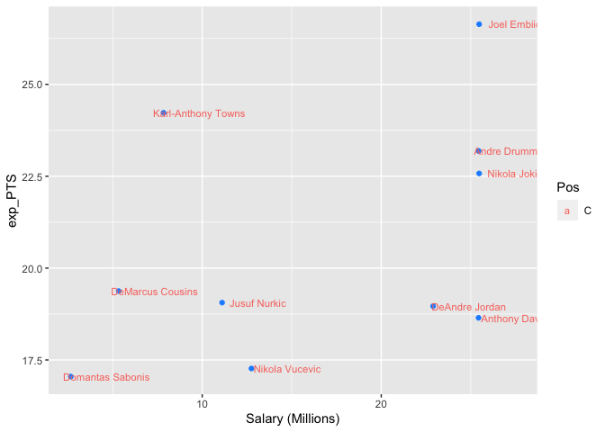

[figure not shown]

Karl-Anthony Towns & DeMarcus Cousins, are two players suited for center position. We can see that Karl-Anthony Towns has exp_PTS of 24.2 at just 7.83 millions. So, he is our player for center position. We can put DeMarcus Cousins for bench strength.

### Lets save the processed data

```r
write_csv(x = final_players, path = "data/processed/finalplayers.csv")
write_csv(x = normalised_player_stat, path = "data/processed/playersstat.csv")
write_csv(x = normalised_team_stat, path = "data/processed/teamstat.csv")
```

## 6. Summary

```
##   POSITION             PLAYER SALARYmillions
## 1       PG        Ben Simmons           6.43
## 2       SG       Devin Booker           3.31
## 3       SF     Brandon Ingram           5.75
## 4       PF      Julius Randle           8.64
## 5        C Karl-Anthony Towns           7.83
## 6                       TOTAL          31.96
```

## 7. Reference List

1. [Internet]. Rstudio.com. 2022 [cited 3 May 2022]. Available from: https://www.rstudio.com/wp-content/uploads/2015/02/rmarkdown-cheatsheet.pdf
2. Chicago Bulls Basketball - Bulls News, Scores, Stats, Rumors & More | ESPN [Internet]. ESPN. 2022 [cited 3 May 2022]. Available from: https://www.espn.in/nba/team/_/name/chi/chicago-bulls
3. García J, Ibáñez S, Martinez De Santos R, Leite N, Sampaio J. Identifying Basketball Performance Indicators in Regular Season and Playoff Games. Journal of Human Kinetics [Internet]. 2013 [cited 27 April 2022];36(1):161-168. Available from: https://www.ncbi.nlm.nih.gov/pmc/articles/PMC3661887/
4. Csataljay G, O’Donoghue P, Hughes M, Dancs H. Performance indicators that distinguish winning and losing teams in basketball. International Journal of Performance Analysis in Sport [Internet]. 2009 [cited 1 May 2022];9(1):60-66. Available from: https://www.researchgate.net/publication/233682287_Performance_indicators_that_distinguish_winning_and_losing_teams_in_basketball
5. NBA Players & Team Rosters | NBA.com [Internet]. Nba.com. 2022 [cited 3 May 2022]. Available from: https://www.nba.com/players